# VendingVitals

Marissa Cruse & Alyssa Felix Arreola

2023-12-13

## Introduction

### Heroin and Drug Overdoses in Cincinnati and Harm Reduction Measures

The United States faces a large opioid crisis, where opioid misuses and deaths continue to increase. In 2017, Ohio experienced the second highest overdose rates in the United States, where the city of Cincinnati experienced a 50% rise since 2015 [1]. In understanding this, Cincinnati was one of the 12 hotspots in Ohio for highest per capita rates of fatal overdose between 2010 and 2017 [1]. Heroin overdose incidences, in connection, remain high, leading to public health issues such as HIV and need-borne diseases.

To decrease these high overdose rates, harm reduction vending machines (HRVMs) have been used as an accessible method for those who use drugs for risk reduction and prevention resources including naloxone, fentanyl testing strips, sterile syringes, tourniquets, and bandages. According to the Center for Disease Control and Prevention (CDC), HRVMs are a lower-barrier mode of accessing harm reduction, in place of harm reduction programs or reach sites that have harm reduction resources [2]. Carocole, an HIV/AIDs service organization in Cincinnati, has brought the HRVM to this city, in partnership with Interact for Health. The machine was located outside of Caracole’s building on Hamilton Avenue and made accessible 24/7 [3]. In order to use the machine, users had to complete an anonymous survey, in which they were given an access code to use for the vending machine that was good for 90 days.

Through enrolling, users are given access to harm reduction counselors that offer additional information on HIV and hepatitis C prevention and testing information, local housing programs, counseling, substance use disorder medical treatment and prenatal care. Within the vending machine, each person can dispense two injection doses, two nasal spray doses of naloxone, a container for disposing sharp objects, a safer injection kit, a smoking kit, a personal protective equipment kit, a safer sex kit, a pregnancy test and a box of bandages from the machine every seven days [3].

In the installation of the vending machine until December 2022, users reported that 960 overdoses were reversed using naloxone from the machine. In this event, while the national overdose deaths increased by 15 percent, Hamilton County, in Cincinnati, decreased by 10 percent [3]. While there are many variables to consider, the University of Cincinnati’s, Daniel Arendt, Doctor of Pharmacy, expressed that he believes this vending machine made a large impact [3]. Within its first year, the machine dispensed 3,360 doses of naloxone and 10,155 fentanyl test strips, with 911 users, 16 percent of whom had never used harm reduction services before [3].

### How is Vending Vitals able to predict future heroin overdoses?

Our analysis uses a geospatial risk model. This is a regression model, where the dependent variable is the occurrence of different events, in this case being overdoses. The predictions in using this model will forecast the risk of overdose occurring in certain locations.

In predicting overdose in Cincinnati, this app functions under the hypothesis that overdose risk is a function of exposure to different geospatial risk and protective factors, such as Police Calls related to drug activity and locations of vacant lots.

### What does Vending Vitals provide to public health officials in regard to predicting heroin overdoses and placing vending machines?

```r
library(patchwork)
library(tidyverse)
library(sf)
library(RSocrata)
library(viridis)
library(spatstat.explore)
library(raster)
library(spdep)
library(FNN)
library(grid)
library(gridExtra)
library(knitr)
library(kableExtra)
library(tidycensus)
library(classInt)
library(dplyr)
library(tigris)
library(tidygeocoder)
library(ggmap)
library(tidyr)
library(spatstat)
root.dir = "https://raw.githubusercontent.com/urbanSpatial/Public-Policy-Analytics-Landing/master/DATA/"
source("https://raw.githubusercontent.com/urbanSpatial/Public-Policy-Analytics-Landing/master/functions.r")
```

```r
project_crs = ('EPSG:3735')
library(showtext)

font_add("Times New Roman", regular = "times.ttf", bold = "timesbd.ttf", italic = "timesi.ttf", bolditalic = "timesbi.ttf")

showtext_auto()

map_theme <- function() {
  theme_minimal() +
    theme(
      axis.line = element_blank(),
      axis.text = element_blank(),
      axis.title = element_blank(),
      axis.ticks = element_blank(),
      panel.grid = element_blank(),
      plot.title = element_text(family = "Times New Roman", size = 18, hjust = 0, face = "bold"),  # Make plot title bold
      plot.subtitle = element_text(family = "Times New Roman", face = "italic"),  # Make subtitle italic
      text = element_text(family = "Times New Roman")
    )
}
```

## Data Wrangling

The analysis uses overdose, drug related police calls, vacant lot locations, and demographic data from the ACS.

```r
boundary <- st_read("C:/Users/cruse/Downloads/Cincinnati_City_Boundary/Cincinnati_City_Boundary.shp")
```

```r
fishnet <-
  st_make_grid(boundary,
               cellsize = 500,
               square = TRUE) %>%
  .[boundary] %>%
  st_sf() %>%
  mutate(uniqueID = 1:n())
```

```r
overdose <- read.socrata("https://data.cincinnati-oh.gov/resource/w46w-g9g7.json") %>%
  filter(!is.na(latitude_x) & !is.na(longitude_x))%>%
  filter(year(create_time_incident) == 2021) %>%
  mutate(legend = "overdose_incidents")
write.csv(overdose, file = "C:/Users/cruse/OneDrive/Desktop/PPA/overdose", row.names = FALSE)
rm(overdose)
```

```r
overdose <- read.csv("C:/Users/cruse/OneDrive/Desktop/PPA/overdose") %>%
  st_as_sf(coords = c("longitude_x", "latitude_x"), remove = FALSE) %>%
  st_set_crs('EPSG:4326') %>%
  dplyr::select(geometry, legend)

overdose <- st_transform(overdose, crs = project_crs)
```

```r
drug_calls <- read.socrata("https://data.cincinnati-oh.gov/resource/gexm-h6bt.json")%>%
  filter(!is.na(latitude_x) & !is.na(longitude_x))%>%
  filter(incident_type_id %in% c("DRUG", "DISORD") & year(create_time_incident) == 2021) %>%
  mutate(legend = "drug_calls")

write.csv(drug_calls, file = "C:/Users/cruse/OneDrive/Desktop/PPA/drug_calls", row.names = FALSE)
rm(drug_calls)
```

```r
drug_calls <- read.csv("C:/Users/cruse/OneDrive/Desktop/PPA/drug_calls") %>%
  st_as_sf(coords = c("longitude_x", "latitude_x"), remove = FALSE) %>%
  st_set_crs('EPSG:4326') %>%
  dplyr::select(geometry, legend)

drug_calls <- st_transform(drug_calls, crs = project_crs)
```

```r
vacant <- read.csv("C:/Users/cruse/Downloads/vacantbldgs (1).csv")
vacant$complete_address <- paste(vacant$ADDRESS, ", Cincinnati, OH", sep = " ")

register_google(key = "AIzaSyAZRaWpH-a6aM-Ac7Ln9nObYNPlasBn3Yg")
vacant <- vacant %>%
  tidygeocoder::geocode(
    address = complete_address,
    method = "osm"
  )

write.csv(vacant, file = "C:/Users/cruse/OneDrive/Desktop/PPA/vacant", row.names = FALSE)
rm(vacant)
```

```r
vacant <- read.csv("C:/Users/cruse/OneDrive/Desktop/PPA/vacant")
vacant <- vacant[complete.cases(vacant[c("lat", "long")]), ]
vacant <- st_as_sf(vacant, coords = c("long", "lat"))%>%
  st_set_crs('EPSG:4326')
vacant <- st_transform(vacant, crs = project_crs)
vacant <- vacant %>%
  mutate(legend = "vacant")%>%
  dplyr::select(geometry, legend)
```

```r
cincinnati_demographic_data <-
  get_acs(geography = "tract", variables = c("B01001_001E","B01001A_001E","B06011_001", "B15002_014E", "B15002_001E", "B01001_010E", "B01001_011E", "B01001_012E"),
          year = 2021, state=39, county=061, geometry=T, output = "wide") %>%
  st_set_crs(4326)  %>%
  rename(TotalPop = B01001_001E,
         NumberWhites = B01001A_001E,
         Median_Income = B06011_001E,
         Bachelors_Pop = B15002_014E,
         Tot_Pop_edu = B15002_001E,
         age_35_39 = B01001_010E,
         age_40_44 = B01001_011E,
         age_45_49 = B01001_012E) %>%
  mutate(percentWhite = NumberWhites / TotalPop,
         percentBachelors = Bachelors_Pop/Tot_Pop_edu,
         percentNonWhite = (1 - percentWhite),
        age_35_49 = age_35_39 + age_40_44 + age_45_49)
cincinnati_demographic_data <- st_transform(cincinnati_demographic_data, crs = project_crs)
cincinnati_demographic_data <- st_intersection(cincinnati_demographic_data, boundary)

cincinnati_demographic_data <- cincinnati_demographic_data %>%
  dplyr::select(geometry, percentBachelors, age_35_49, Median_Income)
```

## Exploratory Analysis & Vizualizations

### Creating a Fishnet of Cincinnati

To represent the spatial trend of overdose incidents in Cincinnati, OH, we aggregate point level data into a lattice of grid cells, or a fishnet of the boundary of Cincinnati.

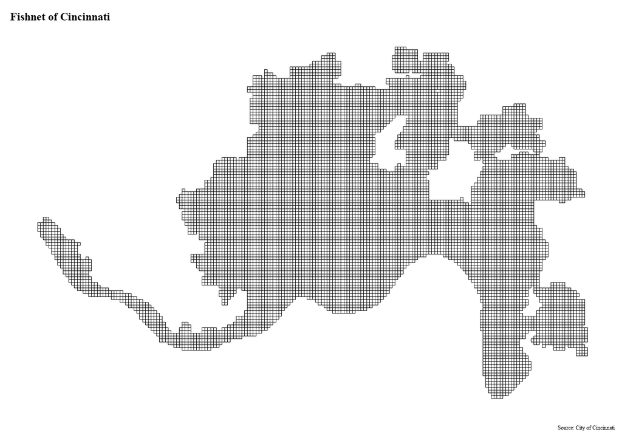

```r
ggplot() +
  geom_sf(data = fishnet, color = "black", fill = "white") +
  labs(title = "Fishnet of Cincinnati",
       caption = "Source: City of Cincinnati") +
  theme_void() +
  map_theme()
```

### Observing Densisity of Overdoses in Cincinnati, Ohio

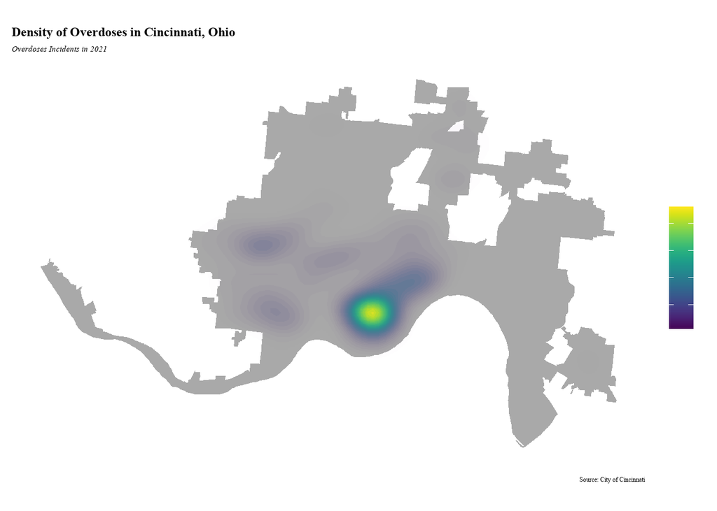

```r
ggplot() +
  geom_sf(data = boundary, fill = "darkgrey", color = alpha("white", 0)) +
  stat_density2d(data = data.frame(st_coordinates(overdose)),
                 aes(X, Y, fill = ..level.., alpha = ..level..),
                 size = 0.01, bins = 40, geom = 'polygon') +
  scale_fill_viridis() +
  scale_alpha(range = c(0.00, 0.35), guide = FALSE) +
  labs(title = "Density of Overdoses in Cincinnati, Ohio",
       subtitle = "Overdoses Incidents in 2021",
       caption = "Source: City of Cincinnati") +
  theme_void()  +
  map_theme() +
  theme(
    legend.title = element_blank(),
    legend.text = element_blank(),
    plot.title = element_text(hjust = 0)
  )
```

### Joining Overdoses to the Fishnet

Using overdose data from the City of Cincinnati, the overdose data is joined to fishnet data to sum each overdose incident by grid lattice cell. A ‘cvID’ column is created for cross-validation and a ’uniqueID’column is created to assign an ID to each grid cell.

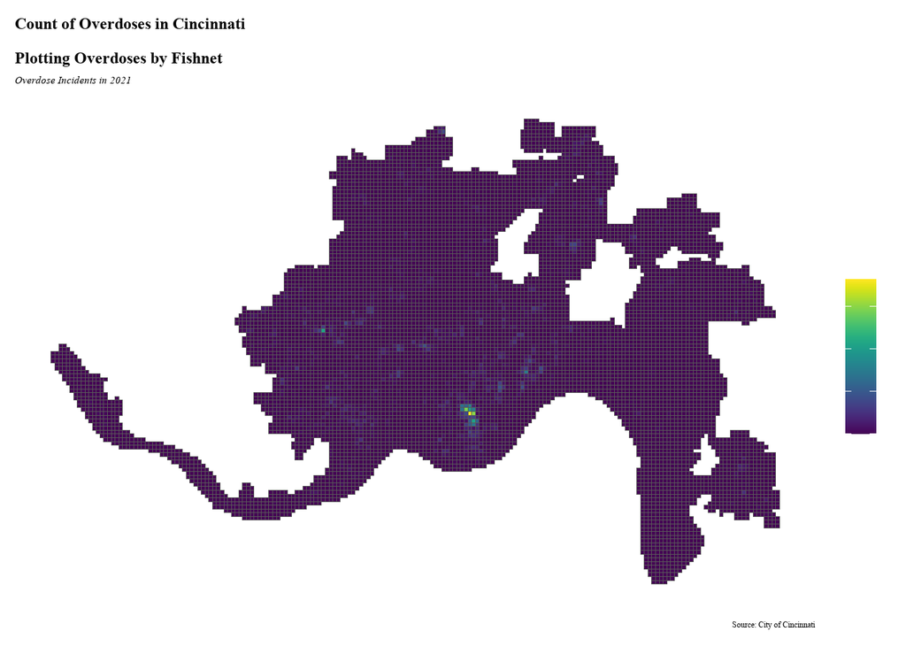

```r
overdose_net <-
  dplyr::select(overdose) %>%
  mutate(countOD = 1) %>%
  aggregate(., fishnet, sum) %>%
  mutate(countOD = replace_na(countOD, 0),
         uniqueID = rownames(.),
         cvID = sample(round(nrow(fishnet) / 96), size=nrow(fishnet), replace = TRUE))

ggplot() +
  geom_sf(data = overdose_net, aes(fill = countOD)) +
  scale_fill_viridis() +
  labs(title = "Count of Overdoses in Cincinnati \nPlotting Overdoses by Fishnet",
       subtitle = "Overdose Incidents in 2021",
       caption = "Source: City of Cincinnati") +
  map_theme()+
  theme(
    legend.title = element_blank(),
    legend.text = element_blank()
  )
```

```r
vars_net <-
  rbind(vacant, drug_calls) %>%
  st_join(., fishnet, join=st_within) %>%
  st_drop_geometry() %>%
  group_by(uniqueID, legend) %>%
  summarize(count = n()) %>%
    full_join(fishnet) %>%
    spread(legend, count, fill=0) %>%
    st_sf() %>%
    dplyr::select(-`<NA>`) %>%
    na.omit() %>%
    ungroup()

vars_net <- st_join(vars_net, cincinnati_demographic_data)
```

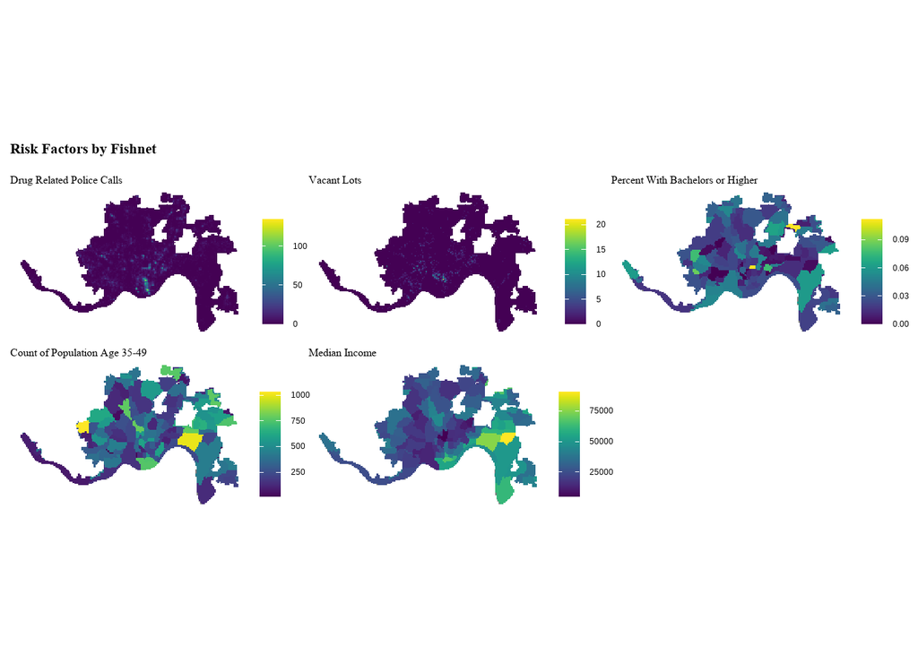

```r
vars_net.long <-
  gather(vars_net, Variable, value, -geometry, -uniqueID)

vars <- unique(vars_net.long$Variable)
mapList <- list()
titles <- c("Drug Related Police Calls", "Vacant Lots", "Percent With Bachelors or Higher", "Count of Population Age 35-49", "Median Income", "Vacant Lots NN", "Drug Related Police Calls NN")
for(i in vars){
  mapList[[i]] <-
    ggplot() +
      geom_sf(data = filter(vars_net.long, Variable == i), aes(fill=value), colour=NA) +
      scale_fill_viridis(name="") +
      labs(title= titles[which(vars ==i)]) +
      theme_void()+
      theme(
      axis.line = element_blank(),
      axis.text = element_blank(),
      axis.title = element_blank(),
      axis.ticks = element_blank(),
      panel.grid = element_blank(),
      plot.title = element_text(family = "Times New Roman", size = 12, hjust = 0),  # Adjust legend title size
        legend.key.size = unit(.8, "lines"))}

combined_plots <- wrap_plots(mapList, ncol = 3) + plot_annotation(title = "Risk Factors by Fishnet", theme = theme(plot.title = element_text(family = "Times New Roman", size = 16, face = "bold")))

# Print or display the combined plots
print(combined_plots)
```

## Feature Engineering

```r
vars_coordinates <- (st_coordinates(st_centroid(vars_net)))
vacant_coordinates <- st_coordinates(vacant)
drugcall_coordinates <- st_coordinates(drug_calls)

vars_net <-
  vars_net %>%
    mutate(
      vacant.nn = nn_function(vars_coordinates, vacant_coordinates, k=3),
      drug_calls.nn = nn_function(vars_coordinates, drugcall_coordinates, k=3))
```

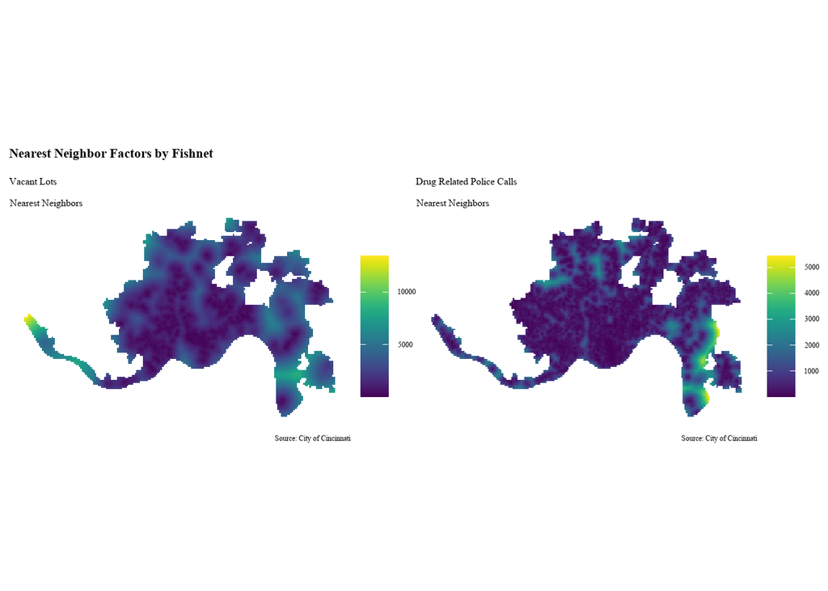

```r
vars_net.long.nn <-
  dplyr::select(vars_net, ends_with(".nn")) %>%
    gather(Variable, value, -geometry)

vars <- unique(vars_net.long.nn$Variable)
mapList <- list()

for (i in vars) {
  title_text <- switch(i,
    "vacant.nn" = "Vacant Lots \nNearest Neighbors",
    "drug_calls.nn" = "Drug Related Police Calls \nNearest Neighbors",
  )

  mapList[[i]] <-
    ggplot() +
    geom_sf(data = filter(vars_net.long.nn, Variable == i), aes(fill = value), colour = NA) +
    scale_fill_viridis(name = "") +
    labs(title = title_text,
         caption = "Source: City of Cincinnati") +
    theme_void()+
    theme(
      axis.line = element_blank(),
      axis.text = element_blank(),
      axis.title = element_blank(),
      axis.ticks = element_blank(),
      panel.grid = element_blank(),
      plot.subtitle = element_text(family = "Times New Roman", face = "italic"),
      text = element_text(family = "Times New Roman"),
      plot.title = element_text(family = "Times New Roman", size = 12, hjust = 0)
    )
}

combined_plots1 <- wrap_plots(mapList, ncol = 2) + plot_annotation(title = "Nearest Neighbor Factors by Fishnet", theme = theme(plot.title = element_text(family = "Times New Roman", size = 16, face = "bold")))

print(combined_plots1)
```

## Understanding the Spatial Process of Overdoses in Cincinnati

Spatial Autocorrelation refers to the tendency of similar values to occur near each other in geographic space. Understanding spatial autocorrelation is important because it reveals patters in spatial data. To test for spatial autocorrelation for our variables, we use a Local Moran’s I test.

```r
vars_net$uniqueID <- as.character(vars_net$uniqueID)

final_net <-
  left_join(overdose_net, st_drop_geometry(vars_net), by="uniqueID")
final_net.nb <- poly2nb(as_Spatial(final_net), queen=TRUE)
final_net.weights <- nb2listw(final_net.nb, style="W", zero.policy=TRUE)
```

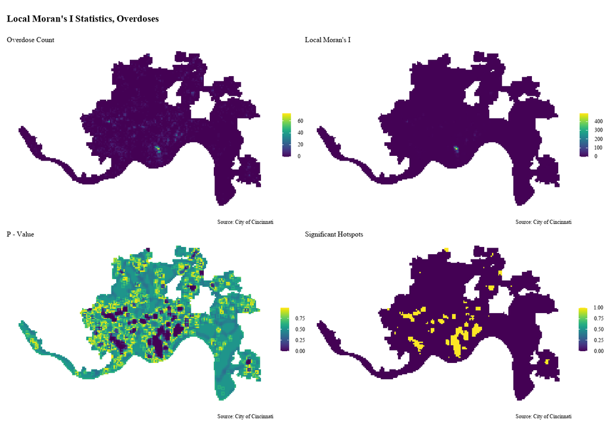

```r
final_net.localMorans <-
  cbind(
    as.data.frame(localmoran(final_net$countOD, final_net.weights)),
    as.data.frame(final_net)) %>%
    st_sf()

final_net.localMorans<- final_net.localMorans%>%
      dplyr::select(Overdose_Count = countOD,
                    Local_Morans_I = Ii,
                    P_Value = `Pr(z != E(Ii))`) %>%
      mutate(Significant_Hotspots = ifelse(P_Value <= 0.05, 1, 0)) %>%
      gather(Variable, Value, -geometry)

vars <- unique(final_net.localMorans$Variable)
varList <- list()

for(i in vars){title_text2 <- switch(i,

    "P_Value" = "P - Value",
    "Local_Morans_I" = "Local Moran's I",
    "Overdose_Count" = "Overdose Count",
    "Significant_Hotspots" = "Significant Hotspots"
  )
  varList[[i]] <-
    ggplot() +
      geom_sf(data = filter(final_net.localMorans, Variable == i),
              aes(fill = Value), colour=NA) +
      scale_fill_viridis(name="") +
      labs(title = title_text2,
         caption = "Source: City of Cincinnati") +
    theme_void()+
    theme(
      axis.line = element_blank(),
      axis.text = element_blank(),
      axis.title = element_blank(),
      axis.ticks = element_blank(),
      panel.grid = element_blank(),
      plot.subtitle = element_text(family = "Times New Roman", face = "italic"),
      text = element_text(family = "Times New Roman"),
      plot.title = element_text(family = "Times New Roman", size = 12, hjust = 0),,  #
        legend.key.size = unit(.5, "lines")
    )}

combined_plots2 <- wrap_plots(varList, ncol = 2) + plot_annotation(title = "Local Moran's I Statistics, Overdoses", theme = theme(plot.title = element_text(family = "Times New Roman", size = 16, face = "bold")))

print(combined_plots2)
```

```r
final_net <-
  final_net %>%
  mutate(overdose.isSig =
           ifelse(localmoran(final_net$countOD,
                             final_net.weights)[,5] <= 0.0000001, 1, 0)) %>%
  mutate(overdose.isSig.dist =
           nn_function(st_coordinates(st_centroid(final_net)),
                       st_coordinates(st_centroid(
                         filter(final_net, overdose.isSig == 1))), 1))
```

## Correlation Tests

Running correlation tests will allow for some variables to be eliminated from our model. Predictors with an r absolute value of less than 0.15 will be eliminated from the model. After running these correlation tests, the final model that includes risk factors only will include drug related police calls, vacant lots, drug related police calls nearest neighbors, vacant lots nearest neighbors.The final model including spatial autocorrelation variables will also use these risk factors.Predictors related to the demographics of Cincinnati have been eliminated.

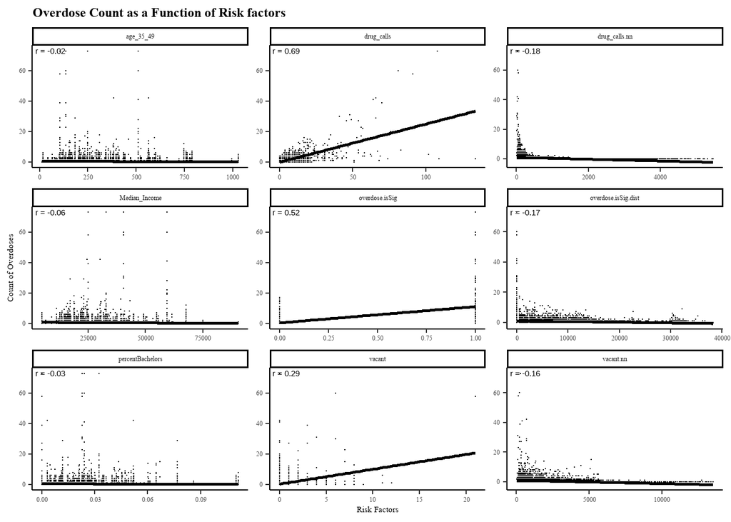

```r
correlation.long <-
  st_drop_geometry(final_net) %>%
    dplyr::select(-uniqueID, -cvID) %>%
    gather(Variable, Value, -countOD)

correlation.cor <-
  correlation.long %>%
    group_by(Variable) %>%
    summarize(correlation = cor(Value, countOD, use = "complete.obs"))

ggplot(correlation.long, aes(Value, countOD)) +
  geom_point(size = 0.1) +
  geom_text(data = correlation.cor, aes(label = paste("r =", round(correlation, 2))),
            x = -Inf, y = Inf, vjust = 1.5, hjust = -0.1) +
  geom_smooth(method = "lm", se = FALSE, colour = "black") +
  facet_wrap(~Variable, ncol = 3, scales = "free") +
  labs(
    title = "Overdose Count as a Function of Risk factors",
    x = "Risk Factors",  # Label for x-axis
    y = "Count of Overdoses"  # Label for y-axis
  ) +
  theme_classic()+
  theme(
    plot.title = element_text(family = "Times New Roman", size = 18, hjust = 0, face = "bold"),
    plot.subtitle = element_text(family = "Times New Roman", face = "italic"),
    text = element_text(family = "Times New Roman")
  )
```

## Cross-Validated Poisson Regression

Cross Validation tests for 2 regressions, one including just risk predictors and a second including the risk factors and the Local Moran’s I spatial process features were ran .The cross validation function will use the selected variables to train a model and predict overdose incidence for each grid cell.

```r
reg.vars <- c("drug_calls", "vacant", "vacant.nn", "drug_calls.nn")

reg.ss.vars <- c("drug_calls", "vacant", "vacant.nn", "drug_calls.nn","overdose.isSig")
```

```r
reg.cv <- crossValidate(
  dataset = final_net,
  id = "cvID",
  dependentVariable = "countOD",
  indVariables = reg.vars) %>%
    dplyr::select(cvID = cvID, countOD, Prediction, geometry)

reg.ss.cv <- crossValidate(
  dataset = final_net,
  id = "cvID",
  dependentVariable = "countOD",
  indVariables = reg.ss.vars) %>%
    dplyr::select(cvID = cvID, countOD, Prediction, geometry)
```

## Accuracy and Generalizability

### Accuracy

To test for accuracy, mean absolute error is calculated for each fold for both regressions. After plotting the distribution of the MAE, it seems that the spatial process reduces error for our model.

```r
reg.summary <-
  rbind(
    mutate(reg.cv,           Error = Prediction - countOD,
                             Regression = "Random k-fold CV: Just Risk Factors"),

    mutate(reg.ss.cv,        Error = Prediction - countOD,
                             Regression = "Random k-fold CV: Spatial Process")) %>%
    st_sf()
```

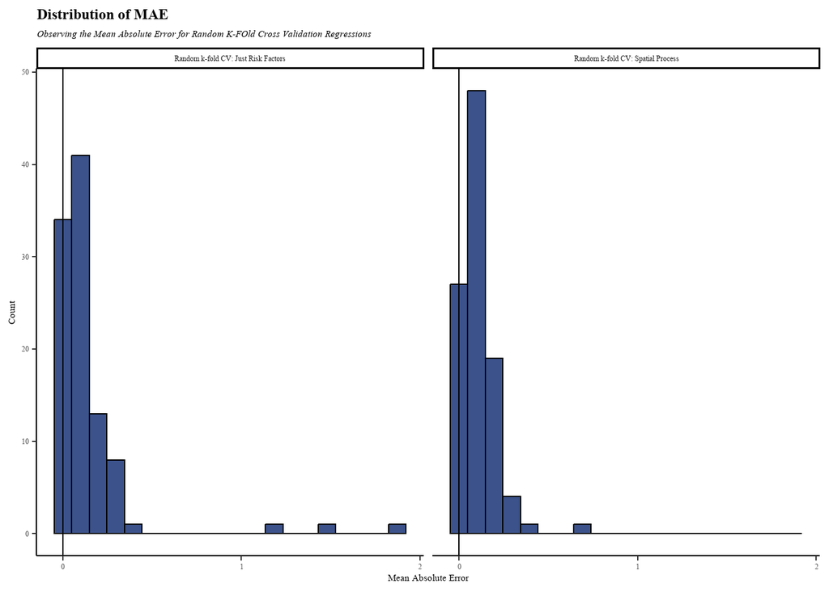

```r
error_by_reg_and_fold <-
  reg.summary %>%
    group_by(Regression, cvID) %>%
    summarize(Mean_Error = mean(Prediction - countOD, na.rm = T),
              MAE = mean(abs(Mean_Error), na.rm = T),
              SD_MAE = mean(abs(Mean_Error), na.rm = T)) %>%
  ungroup()

error_by_reg_and_fold %>%
  ggplot(aes(MAE)) +
    geom_histogram(bins = 20, colour="black", fill = "#3b528b") +
    facet_wrap(~Regression) +
    geom_vline(xintercept = 0) + scale_x_continuous(breaks = seq(0, 8, by = 1)) +
    labs(title="Distribution of MAE",
         subtitle = "Observing the Mean Absolute Error for Random K-FOld Cross Validation Regressions",
         x="Mean Absolute Error", y="Count") +
  theme_classic()+
  theme(
    plot.title = element_text(family = "Times New Roman", size = 18, hjust = 0, face = "bold"),
    plot.subtitle = element_text(family = "Times New Roman", face = "italic"),
    text = element_text(family = "Times New Roman")
  )
```

The table below presents the mean MAE and the standard deviation of our MAE.The model that includes the spatial process has a lower mean MAE and lower standard deviation of the MAE, indicating this model is more accurate than the model only including risk factors

```r
st_drop_geometry(error_by_reg_and_fold) %>%
  group_by(Regression) %>%
    summarize(Mean_MAE = round(mean(MAE), 2),
              SD_MAE = round(sd(MAE), 2)) %>%
  kable() %>%
    kable_styling("striped", full_width = F) %>%
    row_spec(2, color = "black")
```

| Regression | Mean_MAE | SD_MAE |
| --- | --- | --- |
| Random k-fold CV: Just Risk Factors | 0.15 | 0.26 |
| Random k-fold CV: Spatial Process | 0.11 | 0.10 |

### Generalizability

To test for generalizability, mean error is calculated for two groups: census tracts with a median income that is greater than the median income in Cincinnati (~$45,200), and census tracts with a median income that is less than the median income in Cincinnati. The table presenting mean error for both regressions suggests that the spatial process model is more generalizable because the difference in mean error between the two income groups is lower than the difference in mean error for the model that only includes risk factors.

```r
cincinnati_demographic_data <- cincinnati_demographic_data %>%
  mutate(incomeContext = ifelse(Median_Income > 45200, "greater_income", "lower_income"))
```

```r
reg.summary %>%
    st_centroid() %>%
    st_join(cincinnati_demographic_data) %>%
    na.omit() %>%
      st_drop_geometry() %>%
      group_by(Regression, incomeContext) %>%
      summarize(mean.Error = mean(Error, na.rm = T)) %>%
      spread(incomeContext, mean.Error) %>%
      kable(caption = "Mean Error by Income Context") %>%
        kable_styling("striped", full_width = F)
```

Mean Error by Income Context

| Regression | greater_income | lower_income |
| --- | --- | --- |
| Random k-fold CV: Just Risk Factors | 0.1855596 | -0.0253815 |
| Random k-fold CV: Spatial Process | 0.1276733 | -0.0355019 |

## Comparing Risk Predicitions to 2022 Overdose Incidents

TO validate the model, risk predictions are compared to actual overdose incidents in 2022. Risk categories are caluclated and compared for risk predictions and overdose incidents in 2022. Referencing the map and bar chart from below, we are able to conclude that the model performs well when compared to overdose incident data from 2022.

```r
overdose2022 <- read.socrata("https://data.cincinnati-oh.gov/resource/w46w-g9g7.json") %>%
  filter(!is.na(latitude_x) & !is.na(longitude_x))%>%
  filter(year(create_time_incident) == 2022) %>%
  mutate(legend = "overdose_incidents2022")
write.csv(overdose2022, file = "C:/Users/cruse/OneDrive/Desktop/PPA/overdose2022", row.names = FALSE)
rm(overdose2022)
```

```r
overdose2022 <- read.csv("C:/Users/cruse/OneDrive/Desktop/PPA/overdose2022") %>%
  st_as_sf(coords = c("longitude_x", "latitude_x"), remove = FALSE) %>%
  st_set_crs('EPSG:4326') %>%
  dplyr::select(geometry, legend)

overdose2022 <- st_transform(overdose2022, crs = project_crs)%>%
  .[fishnet,]
```

```r
OD_ppp <- as.ppp(st_coordinates(overdose), W = st_bbox(final_net))
OD_KD <- density.ppp(OD_ppp, 1000)

OD_KDE_sf <- as.data.frame(OD_KD) %>%
  st_as_sf(coords = c("x", "y"), crs = st_crs(final_net)) %>%
  aggregate(., final_net, mean) %>%
  mutate(label = "Kernel Density",
         Risk_Category = ntile(value, 100),
         Risk_Category = case_when(
           Risk_Category >= 90 ~ "90% to 100%",
           Risk_Category >= 70 & Risk_Category <= 89 ~ "70% to 89%",
           Risk_Category >= 50 & Risk_Category <= 69 ~ "50% to 69%",
           Risk_Category >= 30 & Risk_Category <= 49 ~ "30% to 49%",
           Risk_Category >= 1 & Risk_Category <= 29 ~ "1% to 29%"))
OD_KDE_sf <- OD_KDE_sf %>%
  cbind(
    aggregate(
      dplyr::select(overdose2022) %>% mutate(odCount = 1), ., sum) %>%
    mutate(odCount = replace_na(odCount, 0))) %>%
  dplyr::select(label, Risk_Category, odCount)
```

```r
OD_risk_sf <-
  filter(reg.summary, Regression == "Random k-fold CV: Spatial Process") %>%
  mutate(label = "Risk Predictions",
         Risk_Category = ntile(Prediction, 100),
         Risk_Category = case_when(
           Risk_Category >= 90 ~ "90% to 100%",
           Risk_Category >= 70 & Risk_Category <= 89 ~ "70% to 89%",
           Risk_Category >= 50 & Risk_Category <= 69 ~ "50% to 69%",
           Risk_Category >= 30 & Risk_Category <= 49 ~ "30% to 49%",
           Risk_Category >= 1 & Risk_Category <= 29 ~ "1% to 29%"))
OD_risk_sf <- OD_risk_sf %>%
  cbind(
    aggregate(
      dplyr::select(overdose2022) %>% mutate(odCount = 1), ., sum) %>%
      mutate(odCount = replace_na(odCount, 0))) %>%
  dplyr::select(label, Risk_Category, odCount)
```

[figure not shown]

```r
rbind(OD_KDE_sf, OD_risk_sf) %>%
  na.omit() %>%
  gather(Variable, Value, -label, -Risk_Category, -geometry) %>%
  ggplot() +
    geom_sf(aes(fill = Risk_Category), colour = NA) +
    geom_sf(data = sample_n(overdose2022, 3000), size = .5, colour = "black") +
    facet_wrap(~label, ) +
    scale_fill_viridis(discrete = TRUE) +
    labs(title="Comparison of Kernel Density and Risk Predictions",
         subtitle="2021 Overdose risk predictions; 2022 burglaries",
         fill = "Risk Category")+
  map_theme()
```

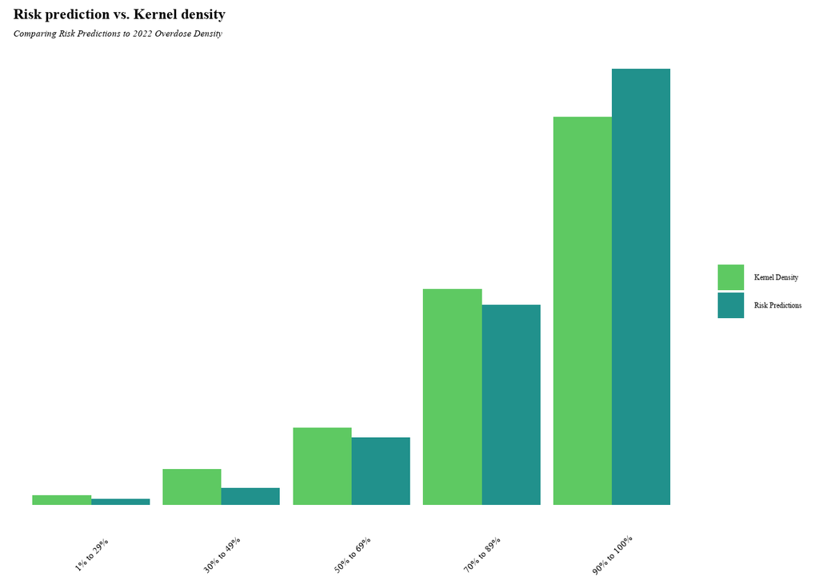

```r
rbind(OD_KDE_sf, OD_risk_sf) %>%
  st_set_geometry(NULL) %>% na.omit() %>%
  gather(Variable, Value, -label, -Risk_Category) %>%
  group_by(label, Risk_Category) %>%
  summarize(countOD = sum(Value)) %>%
  ungroup() %>%
  group_by(label) %>%
  mutate(Rate_of_test_set_crimes = countOD / sum(countOD)) %>%
    ggplot(aes(Risk_Category,Rate_of_test_set_crimes)) +
      geom_bar(aes(fill=label), position="dodge", stat="identity") +
      scale_fill_manual(values = c('#5ec962', '#21918c')) +
      labs(title = "Risk prediction vs. Kernel density",
           subtitle = "Comparing Risk Predictions to 2022 Overdose Density") +
      map_theme() + theme(axis.text.x = element_text(angle = 45, vjust = 0.5))+
  theme(
    legend.title = element_blank()
  )
```

## Locating Vending Machines

Vending Vitals recommends locating vending machines with a predicted risk greater than 90% during the first phase of roll out. After collecting more data and evaluating the effectiveness of the vending machines, Vending Vitals recommends locating vending machines with a predicted risk greater than 70%..

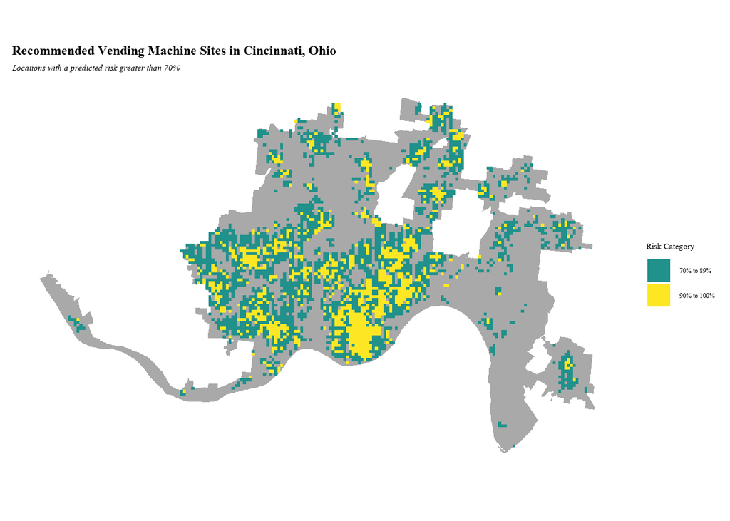

```r
rbind(OD_KDE_sf, OD_risk_sf) %>%
  na.omit() %>%
  gather(Variable, Value, -label, -Risk_Category, -geometry) %>%
    filter(Risk_Category %in% c("70% to 89%", "90% to 100%")) %>%
  ggplot() +
    geom_sf(data = boundary, fill = "darkgrey", color = alpha("white", 0)) +
    geom_sf(aes(fill = Risk_Category), colour = NA)+
    labs(title = "Recommended Vending Machine Sites in Cincinnati, Ohio",
         subtitle = "Locations with a predicted risk greater than 70%",
         fill = "Risk Category")+
    scale_fill_manual(values = c('#21918c', '#fde725')) +
    map_theme()
```

## What Could VendingVitals Do Better?

VendingVital’s model could be improved by adding predictors that improve generalizability. Improving this model’s generalizability would equip the model to handle a diverse range of environments, and allow for the model to be adapted by other cities and organizations seeking to implement a similar program.

## References

[1] Choi, J. I., Lee, J., Yeh, A. B., Lan, Q., & Kang, H. (2022). Spatial clustering of heroin-related overdose incidents: A case study in Cincinnati, Ohio. BMC Public Health, 22(1), 1253. https://doi.org/10.1186/s12889-022-13557-3

[2] Centers for Disease Control and Prevention. (n.d.). Harm Reduction Vending Machines. Harm Reduction Help. Retrieved December 15, 2023, from https://harmreductionhelp.cdc.gov/s/article/Harm-Reduction-Vending-Machines

[3] Caracole. (n.d.). Safer Use Supplies. Caracole. Retrieved December 15, 2023, from https://caracole.org/safer-use-supplies/

[4]University of Cincinnati. (2022, November). UC study: Harm reduction vending machine makes impact. https://www.uc.edu/news/articles/2022/11/uc-study--harm-reduction-vending-machine-makes-impact.html